# "Ford GoBike" Data-set Exploration and Data visualization

## By: Abdelrahman Rashed

DataSet breif:

Bay Wheels is a regional public bicycle sharing system in California's San Francisco Bay Area. It is operated by Motivate in a partnership with the Metropolitan Transportation Commission and the Bay Area Air Quality Management District.Bay Wheels is the first regional and large-scale bicycle sharing system deployed in California and on the West Coast of the United States. It was established as Bay Area Bike Share in August 2013. As of January 2018, the Bay Wheels system had over 2,600 bicycles in 262 stations across San Francisco, East Bay and San Jose.

In June 2017 the system was officially re-launched as Ford GoBike in a partnership with Ford Motor Company. After Motivate's acquisition by Lyft, the system was renamed to Bay Wheels in June 2019. The system is expected to expand to 7,000 bicycles around 540 stations in San Francisco, Oakland, Berkeley, Emeryville, and San Jose.

Here I have investigated the data in (2018) between January till September.

Path for the used data: https://s3.amazonaws.com/fordgobike-data/index.html

```python
import pandas as pd
import numpy as np
import seaborn as sb
import matplotlib.pyplot as plt
import calendar
%matplotlib inline
```

# code to be run once, to combine more than one csv file to one csv file.

extension = 'csv'

# Collect the same files with the same extension

all_filenames = [i for i in glob.glob('*.{}'.format(extension))]

# Combine the csv files which are in the same directory

combined_csv = pd.concat([pd.read_csv(f) for f in all_filenames])

# Export to one CSV

combined_csv.to_csv( "FordBike.csv", index=False, encoding='utf-8-sig')

```python
df = pd.read_csv('FordBike.csv') # Read the dataset into 'df' variable
```

### Early investigation

```python
df.head()
```

|  | duration_sec | start_time | end_time | start_station_id | start_station_name | start_station_latitude | start_station_longitude | end_station_id | end_station_name | end_station_latitude | end_station_longitude | bike_id | user_type | member_birth_year | member_gender | bike_share_for_all_trip |
| --- | --- | --- | --- | --- | --- | --- | --- | --- | --- | --- | --- | --- | --- | --- | --- | --- |
| 0 | 71766 | 2018-03-31 16:58:33.1490 | 2018-04-01 12:54:39.2630 | 4.0 | Cyril Magnin St at Ellis St | 37.785881 | -122.408915 | 6.0 | The Embarcadero at Sansome St | 37.804770 | -122.403234 | 341 | Customer | 1964.0 | Female | No |
| 1 | 62569 | 2018-03-31 19:03:35.9160 | 2018-04-01 12:26:25.0350 | 78.0 | Folsom St at 9th St | 37.773717 | -122.411647 | 47.0 | 4th St at Harrison St | 37.780955 | -122.399749 | 536 | Subscriber | 1984.0 | Male | No |
| 2 | 56221 | 2018-03-31 20:13:13.5640 | 2018-04-01 11:50:14.8400 | 258.0 | University Ave at Oxford St | 37.872355 | -122.266447 | 239.0 | Bancroft Way at Telegraph Ave | 37.868813 | -122.258764 | 3245 | Customer | 1983.0 | Male | No |
| 3 | 85844 | 2018-03-31 11:28:07.6580 | 2018-04-01 11:18:52.6130 | 186.0 | Lakeside Dr at 14th St | 37.801319 | -122.262642 | 340.0 | Harmon St at Adeline St | 37.849735 | -122.270582 | 3722 | Customer | NaN | NaN | No |
| 4 | 1566 | 2018-03-31 23:37:56.6400 | 2018-04-01 00:04:02.8930 | 193.0 | Grand Ave at Santa Clara Ave | 37.812744 | -122.247215 | 196.0 | Grand Ave at Perkins St | 37.808894 | -122.256460 | 2355 | Subscriber | 1979.0 | Male | No |

```python
df.info()
```

```
<class 'pandas.core.frame.DataFrame'>
RangeIndex: 1396765 entries, 0 to 1396764
Data columns (total 16 columns):
 #   Column                   Non-Null Count    Dtype
---  ------                   --------------    -----
 0   duration_sec             1396765 non-null  int64
 1   start_time               1396765 non-null  object
 2   end_time                 1396765 non-null  object
 3   start_station_id         1387026 non-null  float64
 4   start_station_name       1387026 non-null  object
 5   start_station_latitude   1396765 non-null  float64
 6   start_station_longitude  1396765 non-null  float64
 7   end_station_id           1387026 non-null  float64
 8   end_station_name         1387026 non-null  object
 9   end_station_latitude     1396765 non-null  float64
 10  end_station_longitude    1396765 non-null  float64
 11  bike_id                  1396765 non-null  int64
 12  user_type                1396765 non-null  object
 13  member_birth_year        1304810 non-null  float64
 14  member_gender            1305147 non-null  object
 15  bike_share_for_all_trip  1396765 non-null  object
dtypes: float64(7), int64(2), object(7)
memory usage: 170.5+ MB
```

# 1. Data Wrangling

### Issue#1: Drop all the null values inside the dataset

- Dropping all the null will in the worst case drop like 100K rows but it is okay compared with all over number of the dataset.

```python
df.dropna(inplace = True)
df.info()
```

```
<class 'pandas.core.frame.DataFrame'>
Int64Index: 1295345 entries, 0 to 1396764
Data columns (total 16 columns):
 #   Column                   Non-Null Count    Dtype
---  ------                   --------------    -----
 0   duration_sec             1295345 non-null  int64
 1   start_time               1295345 non-null  object
 2   end_time                 1295345 non-null  object
 3   start_station_id         1295345 non-null  float64
 4   start_station_name       1295345 non-null  object
 5   start_station_latitude   1295345 non-null  float64
 6   start_station_longitude  1295345 non-null  float64
 7   end_station_id           1295345 non-null  float64
 8   end_station_name         1295345 non-null  object
 9   end_station_latitude     1295345 non-null  float64
 10  end_station_longitude    1295345 non-null  float64
 11  bike_id                  1295345 non-null  int64
 12  user_type                1295345 non-null  object
 13  member_birth_year        1295345 non-null  float64
 14  member_gender            1295345 non-null  object
 15  bike_share_for_all_trip  1295345 non-null  object
dtypes: float64(7), int64(2), object(7)
memory usage: 168.0+ MB
```

### Issue2: Sperate the 'start_time' to its detailed representation

```python
# Split the 'start_time' column to year, month and day
df[["year", "month", "day"]] = df['start_time'].str.split("-", expand = True)
```

```python
# Seperate between the day column between the day itself from side and the other side the hour, minute and seconds.
df[["hour", "min", "second"]] = df['day'].str.split(":", expand= True)
```

```python
df['day'] = df['day'].str.split(" ", expand = True)
```

```python
df[['day', 'hour']] = df['hour'].str.split(" ", expand = True)
```

```python
df.head()
```

|  | duration_sec | start_time | end_time | start_station_id | start_station_name | start_station_latitude | start_station_longitude | end_station_id | end_station_name | end_station_latitude | ... | user_type | member_birth_year | member_gender | bike_share_for_all_trip | year | month | day | hour | min | second |
| --- | --- | --- | --- | --- | --- | --- | --- | --- | --- | --- | --- | --- | --- | --- | --- | --- | --- | --- | --- | --- | --- |
| 0 | 71766 | 2018-03-31 16:58:33.1490 | 2018-04-01 12:54:39.2630 | 4.0 | Cyril Magnin St at Ellis St | 37.785881 | -122.408915 | 6.0 | The Embarcadero at Sansome St | 37.804770 | ... | Customer | 1964.0 | Female | No | 2018 | 03 | 31 | 16 | 58 | 33.1490 |
| 1 | 62569 | 2018-03-31 19:03:35.9160 | 2018-04-01 12:26:25.0350 | 78.0 | Folsom St at 9th St | 37.773717 | -122.411647 | 47.0 | 4th St at Harrison St | 37.780955 | ... | Subscriber | 1984.0 | Male | No | 2018 | 03 | 31 | 19 | 03 | 35.9160 |
| 2 | 56221 | 2018-03-31 20:13:13.5640 | 2018-04-01 11:50:14.8400 | 258.0 | University Ave at Oxford St | 37.872355 | -122.266447 | 239.0 | Bancroft Way at Telegraph Ave | 37.868813 | ... | Customer | 1983.0 | Male | No | 2018 | 03 | 31 | 20 | 13 | 13.5640 |
| 4 | 1566 | 2018-03-31 23:37:56.6400 | 2018-04-01 00:04:02.8930 | 193.0 | Grand Ave at Santa Clara Ave | 37.812744 | -122.247215 | 196.0 | Grand Ave at Perkins St | 37.808894 | ... | Subscriber | 1979.0 | Male | No | 2018 | 03 | 31 | 23 | 37 | 56.6400 |
| 5 | 281 | 2018-03-31 23:58:07.8050 | 2018-04-01 00:02:49.3590 | 197.0 | El Embarcadero at Grand Ave | 37.808848 | -122.249680 | 200.0 | 2nd Ave at E 18th St | 37.800214 | ... | Subscriber | 1991.0 | Male | No | 2018 | 03 | 31 | 23 | 58 | 07.8050 |

5 rows × 22 columns

### Issue3: Creating the 'age' column from the 'year' and 'birth_date' columns

```python
df['year'] = df['year'].astype(float)
df['Member_age'] = df['year'] - df['member_birth_year']
```

```python
df['Member_age']
```

```
0          54.0
1          34.0
2          35.0
4          39.0
5          27.0
           ...
1396760    21.0
1396761    26.0
1396762    21.0
1396763    39.0
1396764    41.0
Name: Member_age, Length: 1295345, dtype: float64
```

### Issue4: Calculate the duration of trips in minutes

```python
df['trip_duration_minutes'] = df['duration_sec']/60
```

# 2 Univariate Variables Exploration

## 2.1 Number of user trips among the 24 hours

```python
#arrange the hours inisde the 'hour' column
base_color = sb.color_palette()[0]
df_hour = df.copy()
df_hour.sort_values('hour', inplace = True)
```

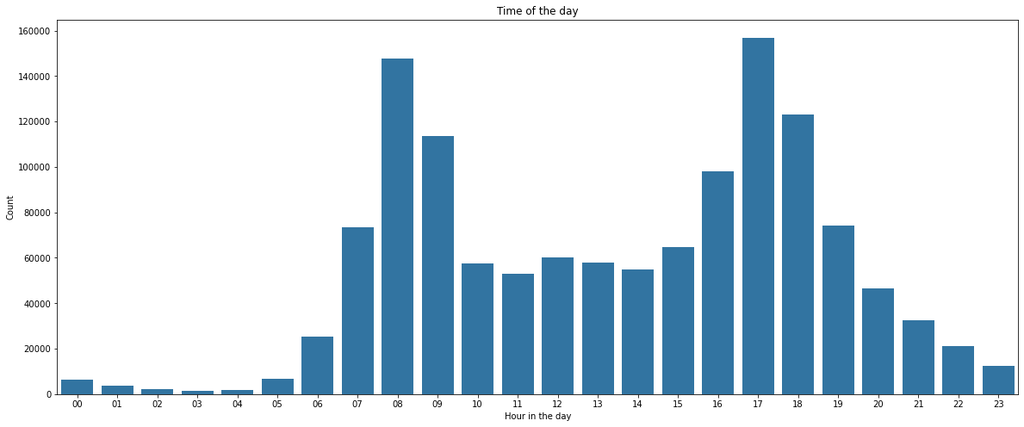

```python
#Using Uni-variate analysis. (Time of the day)
plt.figure(figsize=(20,8))
sb.countplot(data = df_hour, x= 'hour', color = base_color);
plt.xlabel('Hour in the day');
plt.ylabel('Count');
plt.title('Time of the day');
```

- It is bi-model graph.
- And from this quick plot, we can deduce that the most of the rent took place between [7 , 8, 9] in the morning and [16 , 17, 18] in the evening. This could correspond with the rush hour for the schools and jobs.

## 2.2 Number of users trips among months

```python
#arrange the month inisde the 'month' column
df_month = df.copy()
df_month.sort_values('month', inplace = True)
```

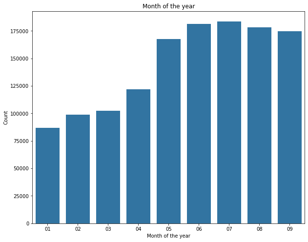

```python
#Using Uni-variate analysis - Countplot. To plot the number of trips across months of the year
plt.figure(figsize=(10,8))
sb.countplot(data = df_month, x= 'month', color = base_color);
plt.xlabel('Month of the year');
plt.ylabel('Count');
plt.title('Month of the year');
```

- This plot is roughly uni-model and left skewed.
- I can deduce from the previous plot that the winter months shows reduction in the number of rent compared to the summer months.

## 2.3 Trip Duration Distribution in minutes

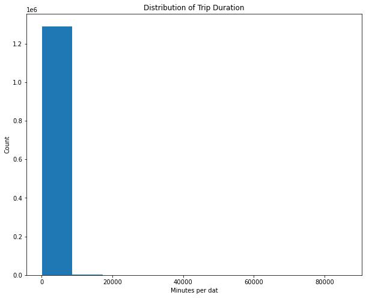

```python
## Using [histogram] from pyplot to reveal the distribution of trip duration in seconds.
plt.figure(figsize = [10,8])
plt.hist(data = df, x = 'duration_sec');
plt.xlabel("Minutes per dat");
plt.ylabel("Count");
plt.title("Distribution of Trip Duration");
```

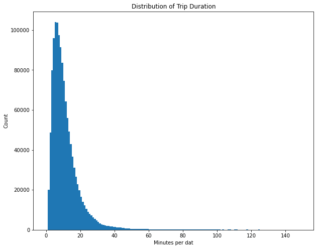

```python
## Using [histogram] from pyplot to reveal the distribution of trip duration in minutes.
bins = np.arange(0, 150 , 1)
plt.figure(figsize = [10,8])
plt.hist(data = df, x = 'trip_duration_minutes', bins = bins);
plt.xlabel("Minutes per dat");
plt.ylabel("Count");
plt.title("Distribution of Trip Duration");
```

## 2.4 Distribution of user types (Customer vs Subscriber)

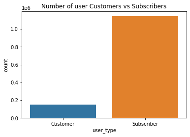

```python
## Using [countplot] from seaborn to find the relation between the number of 'Subscribers' & 'Customers'
sb.countplot(data = df, x = 'user_type');
plt.title('Number of user Customers vs Subscribers');
```

- Comment: Distribution of the Customers and Subscribers in the dataset.

## 2.5 Members age distribution

```python
# Relate the bins to the 'Member_age' values.
bins = np.arange(0, df['Member_age'].max() + 5, 5)
```

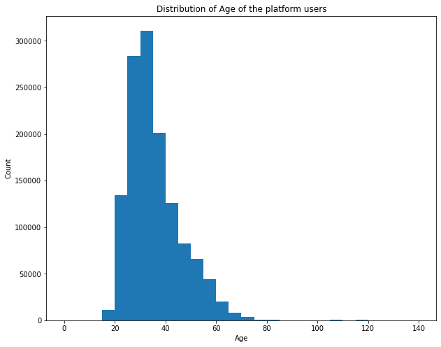

```python
## Using [histogram] from pyplot to reveal the distribution of ages in the dataseet.
plt.figure(figsize = [10,8])
plt.hist(data = df, x = 'Member_age', bins = bins);
plt.xlabel("Age");
plt.ylabel("Count");
plt.title("Distribution of Age of the platform users");
```

- Comment: It is shown here from this graph that average age of the users is located between [20-40] years old.

## 2.6 Gender Distribution

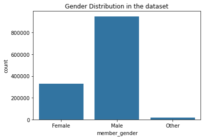

```python
## Using [countplot] from seaborn to plot the distribution of genders in the dataset.
base = sb.color_palette()[0]
#plt.figure(figsize = [10,8])
sb.countplot(data = df, x = 'member_gender', color = base);
plt.title("Gender Distribution in the dataset");
```

- Comment: This show that the male user is much greater than the female user in count.

## 2.7 Trip Count per Month

```python
#change the type of the 'month' column from object to int
df['month']= df['month'].astype(int)
```

```python
#Convert the [month number] to [month name]
df['month'] = df['month'].apply(lambda x: calendar.month_abbr[x])
```

```python
month_order = ["Jan", "Feb", "Mar", "Apr", "May", "Jun", "Jul", "Aug", "Sep"]
```

```python
#Adjust the order of the month inside the 'df' to be plotted
df['month'] = pd.Categorical(df['month'], categories = month_order, ordered = True)
```

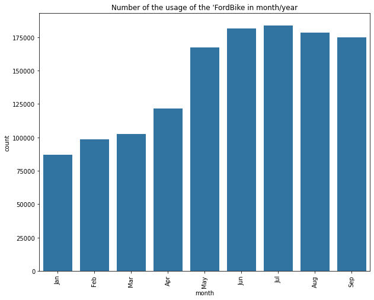

```python
## Using [countplot] from seaborn to plot the distribution of the trips across months of the year.
plt.figure(figsize = [10,8])
sb.countplot(data = df, x = 'month', color = base);
plt.xticks(rotation = 90);
plt.title("Number of the usage of the 'FordBike in month/year");
```

- Commet: Similar graph like section (2.2) but after converting the months to their corresponding names.

## 2.8 Day per week

```python
# Change the type of the 'start_time' varaible from 'object' type to 'datetime' type.
df['start_time'] = pd.to_datetime(df['start_time'])
```

```python
# Generate the weekday from the 'start_time' column.
df['Week_day'] = df.start_time.dt.strftime('%A')
```

```python
days = ["Sunday", "Monday", "Tuesday", "Wednesday", "Thursday", "Friday", "Saturday"]

#Adjust the order of the week days inside the 'df' to be plotted
classes = pd.api.types.CategoricalDtype(categories = days, ordered = True)

#convert the 'week_days' column to ordered categorical type
df['Week_day'] = df['Week_day'].astype(classes);
```

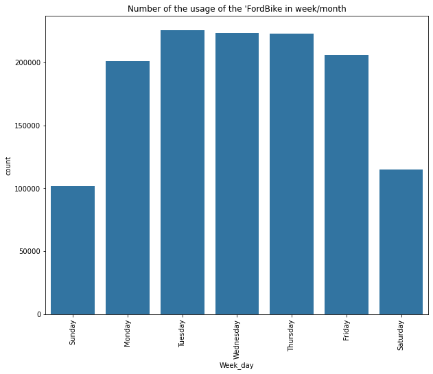

```python
## Using [countplot] from seaborn to plot the distribution of the trips across weekdays.
base = sb.color_palette()[0]
plt.figure(figsize = [10,8])
sb.countplot(data = df, x = 'Week_day', color = base);
plt.xticks(rotation = 90);
plt.title("Number of the usage of the 'FordBike in week/month");
```

- Comment: It is shown here that the drop down in the count of trip during the weekend. This means that the people use the bikes in daily basis. And this also indicate that the users the bike in their normal daily routine.
- This also can show and expresss the robustness and sucess of the system of 'Ford GoBike' that it is able to be reliable and dependable.
- The previous point is also solidated the plot of section "2.4", where the number of subscribers is larger than the number of the customer users.
- Another side point that show the sucess of the system, is that the average age of the users. The average age is around (20-40) which are the group of people that can use public transporation but they have choosed the system. But they are depending on the "Ford GoBike" system and this is indication I'm talking about.

# 3.0 Bivariate variables Exploration

## 3.1 Trip duration vs day of week

```python
print(df['Week_day'].dtype)
```

```
category
```

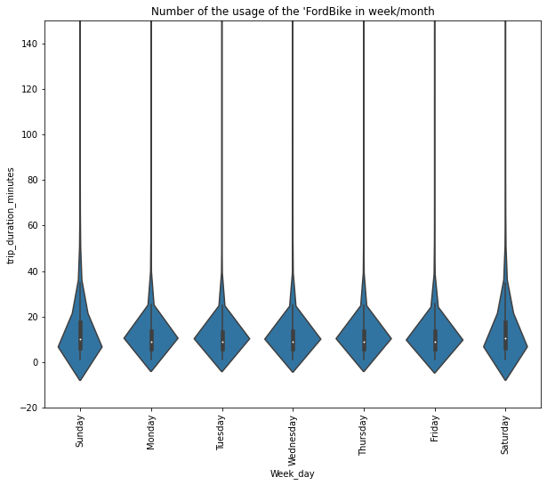

```python
## Using [violinplot] from seaborn to plot weekday versus the trip duration.
plt.figure(figsize = [10,8])
sb.violinplot(data = df, x = 'Week_day', y =  'trip_duration_minutes', color = base_color, innner = None);
plt.xticks(rotation = 90);
plt.ylim( bottom = -20,top = 150);
plt.title("Number of the usage of the 'FordBike in week/month");
```

## 3.2 Member Age vs day of week

```python
# Adjusting the age - Concerning about user below 80
df_age_Adjusted = df.copy()
df_age_Adjusted = df.query('Member_age <= 80')
```

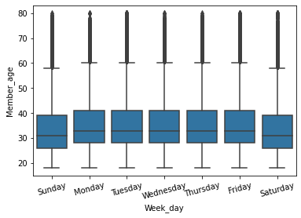

```python
## Using [boxplot] from seaborn to plot the relation between weekday versus member gender.
base = sb.color_palette()[0]
sb.boxplot(data = df_age_Adjusted, x = 'Week_day', y = 'Member_age', color = base);
plt.xticks(rotation =15);
```

## 3.3 week day vs user type

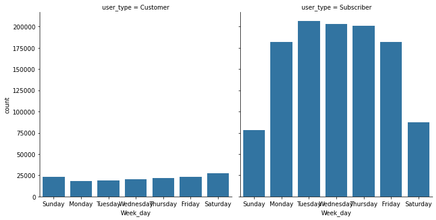

```python
## Using [catplot] from seaborn to plot the user type versus weekday of week.
base = sb.color_palette()[0]
plt.figure(figsize = [10 ,8]);
sb.catplot(data = df_age_Adjusted, x = 'Week_day', col = 'user_type',kind = 'count', color = base);
```

- Comment: By Comparing the relation between the number of the users in the weekend and the weekdays taking in consideration the two cateogires of the user.
- We can see that for subscriber users, they use the system more often in the weekdays compared to the weekend.
- While in the other hand for the customer users it is opposite relationship they use the system more often in the weekend.

## 3.4 Member type vs Member age

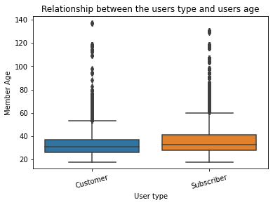

```python
## Using [boxplot] from seaborn to plot the user type versus weekday versus member gender.
sb.boxplot(data = df, x = 'user_type', y =  'Member_age');
plt.xlabel('User type');
plt.ylabel('Member Age');
plt.xticks(rotation = 15);
plt.title('Relationship between the users type and users age');
```

- Comment: We can deduce from this distribtion that average of the ages of the subscriber users tends to be larger than those who are from customer user type.

## 3.5 Trip duration vs Member gender

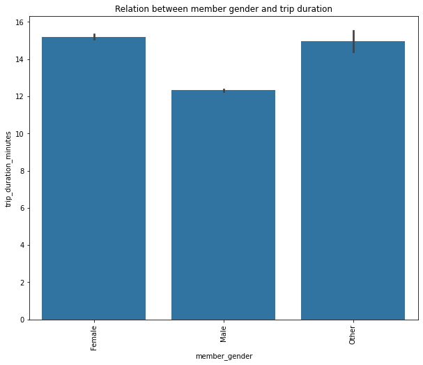

```python
# Using [barplot] from seaborn to plot member gender vs trip duration.
plt.figure(figsize = [10,8])
sb.barplot(data = df, x = 'member_gender', y =  'trip_duration_minutes', color = base_color);
plt.xticks(rotation = 90);
plt.title("Relation between member gender and trip duration");
```

- Comment: From the graph we cann deduce that the male members consume shorter trips than the female members.

## 3.6 Trip duration vs user type

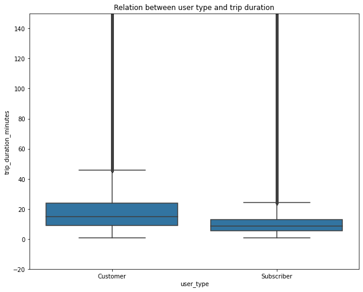

```python
# Using [boxplot] from seaborn to plot the user type versus trip duration.
base_color = sb.color_palette()[0]
plt.figure(figsize = [10,8])
sb.boxplot(data = df, x = 'user_type', y =  'trip_duration_minutes', color = base_color);
plt.ylim( bottom = -20,top = 150);
plt.title("Relation between user type and trip duration");
```

- Comment: We can deduce from this representation that the member from type 'Customer' tends to rent the bikes more time than 'Subscriber' users.
- Comparing this result with the result we get from graph of section "3.3". We can link that the customer users usually use the system for entertainment purposes rather than specific purpose like the subscriber users.

## 3.7 Week Day Vs User Age

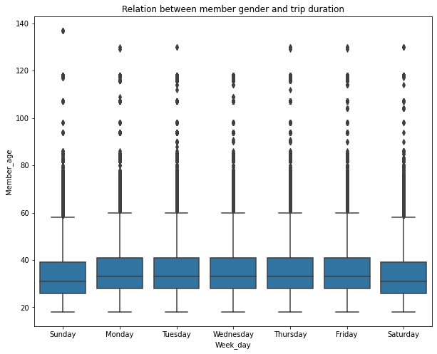

```python
# Using [boxplot] from seaborn to plot the week of the day versus the user age.
base_color = sb.color_palette()[0]
plt.figure(figsize = [10,8])
sb.boxplot(data = df, x = 'Week_day', y = 'Member_age', color = base_color);
plt.title("Relation between member gender and trip duration");
```

# 4.0 Multivariate variables Exploration

## 4.1 Month vs user type vs member gender

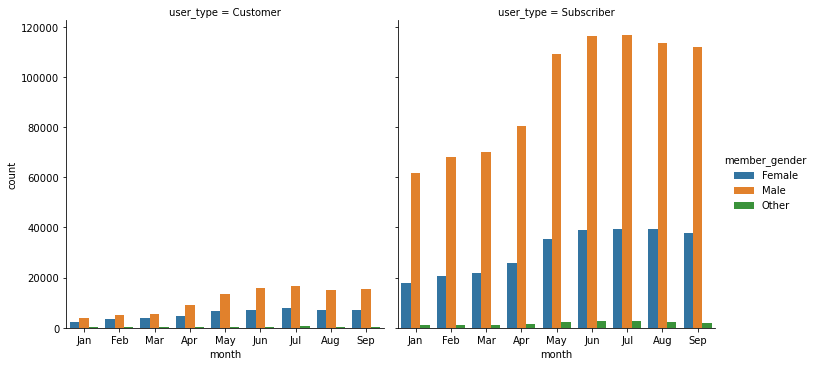

```python
# Using [Catplot] from seaborn to plot the user type versus month versus member gender.
base_color = sb.color_palette()[0]
#plt.figure(figsize = [10,8]);
sb.catplot(data = df, x = 'month', col = 'user_type', hue = 'member_gender', kind = 'count');
```

## 4.2 Week day vs user type vs member age

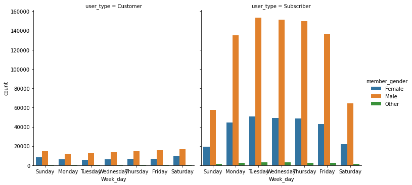

```python
# Using [Catplot] from seaborn to plot the user type versus weekday versus member gender.
base_color = sb.color_palette()[0]
#plt.figure(figsize = [10,8]);
sb.catplot(data = df, x = 'Week_day', col = 'user_type', hue = 'member_gender', kind = 'count');
```

## 4.3 User type vs trip duration vs Gender

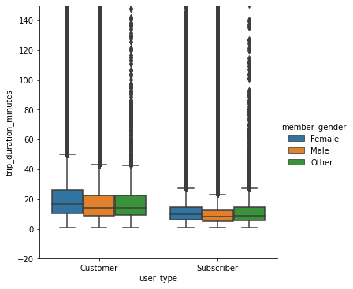

```python
# Using [Catplot] from seaborn with boxplot view to plot the user type versus trip duration versus member gender.
sb.catplot(data = df, x = 'user_type', y = 'trip_duration_minutes', hue = 'member_gender', kind = 'box');
plt.ylim( bottom = -20,top = 150);
```

- Comment: we can see here from this graph from the position of the median (Q2) and the whiskers that the female users are using the system for time than the male users despite their cateogory 'customer' or 'Subscriber'.